# STATS-PRELIM-EXPLOITATION

# 1 Overview

For these exploratory runs there were 100 objectives to optimize, all with the target of 100 and an accuracy requirement of 99%. The population was size 512, and there was a point mutation probability of .7% at each objective. **A solution is considered optimal if all of its traits meet the accuracy requirement.**

# 2 Mu Lambda Selection

## 2.1 Generation Solution Found Data

### 2.1.1 Generation Optimal Solution Found Per Mu

As expected we see that as we increase selection pressure, optimal solutions are found earlier.

```
## notch went outside hinges. Try setting notch=FALSE.
```

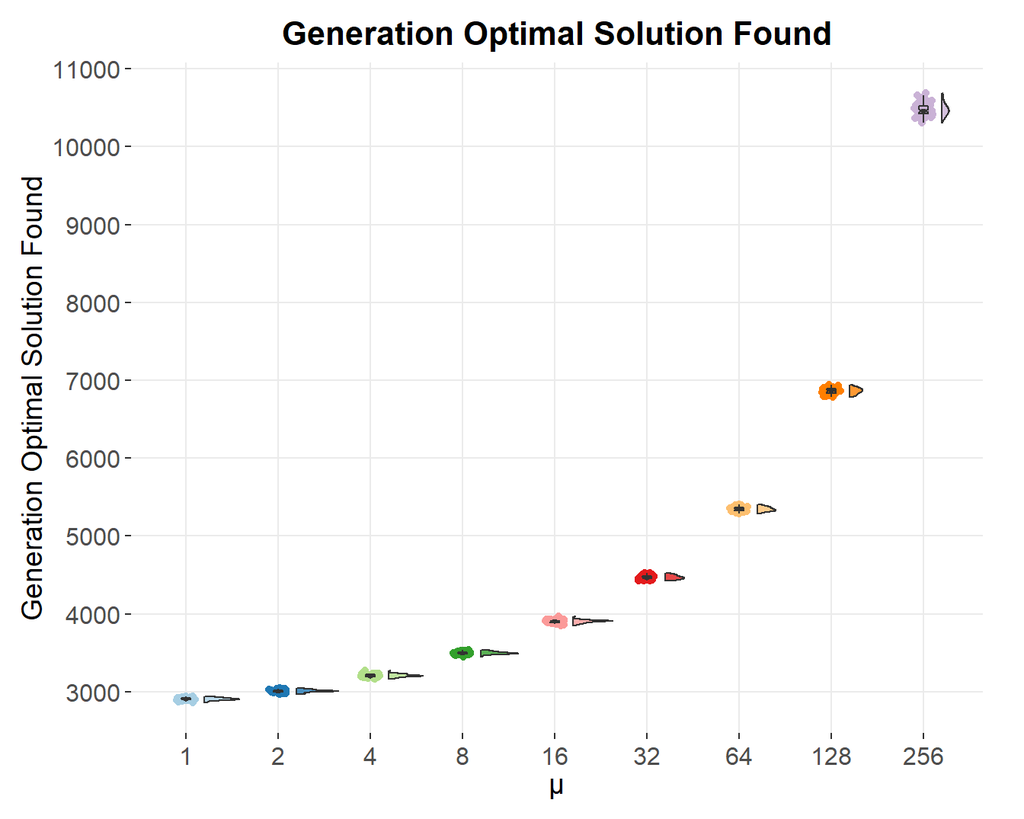

### 2.1.2 Summary Statistics

```r
do.call("rbind", tapply(df$Gen, df$Mu, summary))
```

```
##      Min.  1st Qu.  Median     Mean  3rd Qu.  Max.
## 1    2857  2896.00  2906.0  2905.64  2918.00  2936
## 2    2972  3000.75  3008.5  3009.92  3019.00  3049
## 4    3169  3197.25  3205.5  3207.06  3220.75  3273
## 8    3444  3485.50  3494.5  3496.68  3506.75  3532
## 16   3853  3891.50  3907.0  3902.48  3911.00  3968
## 32   4423  4451.25  4464.5  4468.74  4487.00  4528
## 64   5289  5325.00  5342.5  5345.04  5368.00  5401
## 128  6787  6837.50  6868.0  6863.44  6890.75  6945
## 256 10308 10429.00 10462.5 10480.16 10526.75 10691
```

### 2.1.3 Stats Tests

The Kuskal-Wallis test finds evidence that groups do not come from the same distribution.

```r
kruskal.test(Gen ~ Mu, data = df)
```

```
##
##  Kruskal-Wallis rank sum test
##
## data:  Gen by Mu
## Kruskal-Wallis chi-squared = 443.46, df = 8, p-value < 2.2e-16
```

The pairwaise Wilcoxon rank sum tests show evidence that Mu=1 is statsically lower than all other Mu values.

```r
pairwise.wilcox.test(x = df$Gen, g = df$Mu, p.adjust.method = "bonferroni", paired = FALSE, conf.int = TRUE, conf.level = .95, alternative = 'g')
```

```
##
##  Pairwise comparisons using Wilcoxon rank sum test
##
## data:  df$Gen and df$Mu
##
##     1      2      4      8      16     32     64     128
## 2   <2e-16 -      -      -      -      -      -      -
## 4   <2e-16 <2e-16 -      -      -      -      -      -
## 8   <2e-16 <2e-16 <2e-16 -      -      -      -      -
## 16  <2e-16 <2e-16 <2e-16 <2e-16 -      -      -      -
## 32  <2e-16 <2e-16 <2e-16 <2e-16 <2e-16 -      -      -
## 64  <2e-16 <2e-16 <2e-16 <2e-16 <2e-16 <2e-16 -      -
## 128 <2e-16 <2e-16 <2e-16 <2e-16 <2e-16 <2e-16 <2e-16 -
## 256 <2e-16 <2e-16 <2e-16 <2e-16 <2e-16 <2e-16 <2e-16 <2e-16
##
## P value adjustment method: bonferroni
```

## 2.2 Best Performance Found

We look at the best performances found throughout an evolutionary run to see if there is any differences in performances found.

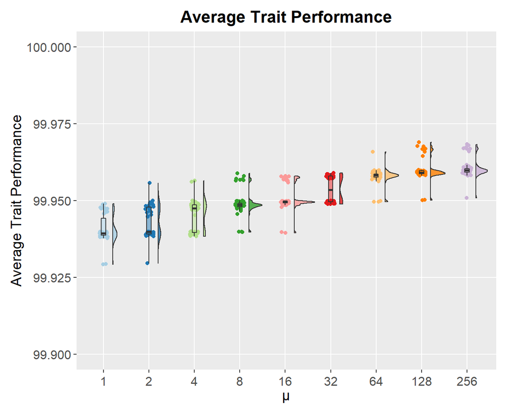

### 2.2.1 Stats Tests

The Kuskal-Wallis test finds evidence that groups do not come from the same distribution.

```r
kruskal.test(val ~ trt, data = df)
```

```
##
##  Kruskal-Wallis rank sum test
##
## data:  val by trt
## Kruskal-Wallis chi-squared = 373.74, df = 8, p-value < 2.2e-16
```

We see that there is no difference in performances found for 128 & 256, in terms of better performances found.

```r
pairwise.wilcox.test(x = df$val, g = df$trt, p.adjust.method = "bonferroni", paired = FALSE, conf.int = TRUE, conf.level = .95, alternative = 'g')
```

```
##
##  Pairwise comparisons using Wilcoxon rank sum test
##
## data:  df$val and df$trt
##
##     1       2       4       8       16      32      64      128
## 2   0.12338 -       -       -       -       -       -       -
## 4   5.4e-05 0.43394 -       -       -       -       -       -
## 8   4.1e-13 8.4e-08 0.00324 -       -       -       -       -
## 16  2.7e-15 2.9e-12 2.3e-09 0.00065 -       -       -       -
## 32  < 2e-16 6.7e-15 3.9e-13 2.8e-09 0.00568 -       -       -
## 64  < 2e-16 < 2e-16 3.4e-16 5.4e-14 5.7e-13 4.9e-05 -       -
## 128 < 2e-16 < 2e-16 < 2e-16 8.2e-16 5.1e-16 5.7e-14 6.0e-07 -
## 256 < 2e-16 < 2e-16 < 2e-16 2.6e-16 2.5e-16 4.2e-15 1.5e-10 0.07625
##
## P value adjustment method: bonferroni
```

# 3 Tournament Selection

Here we explore the impact of different tournament size values on the exploitation diagnostic.

## 3.1 Generation Solution Found Data

### 3.1.1 Generation Optimal Solution Found Per Tournament Size

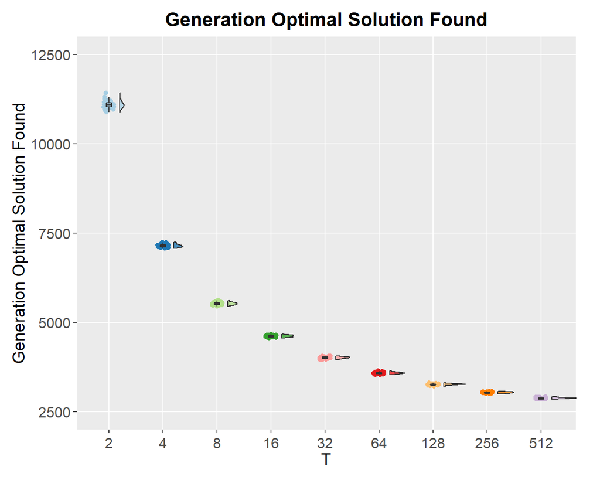

### 3.1.2 Summary Statistics

```r
do.call("rbind", tapply(df$Gen, df$T, summary))
```

```
##      Min.  1st Qu.  Median     Mean  3rd Qu.  Max.
## 2   10886 11033.75 11092.5 11095.54 11151.00 11421
## 4    7082  7120.75  7142.0  7149.06  7170.25  7255
## 8    5454  5503.50  5529.5  5531.62  5554.75  5620
## 16   4568  4599.25  4621.0  4621.24  4644.00  4679
## 32   3963  4003.50  4019.0  4018.66  4036.00  4064
## 64   3543  3571.25  3586.0  3587.20  3602.00  3649
## 128  3220  3264.50  3273.0  3272.94  3284.75  3312
## 256  3009  3029.50  3044.5  3043.76  3057.00  3084
## 512  2850  2876.25  2885.5  2887.06  2896.75  2925
```

### 3.1.3 Stats Tests

The Kuskal-Wallis test finds evidence that groups do not come from the same distribution.

```r
kruskal.test(Gen ~ T, data = df)
```

```
##
##  Kruskal-Wallis rank sum test
##
## data:  Gen by T
## Kruskal-Wallis chi-squared = 443.46, df = 8, p-value < 2.2e-16
```

We see that 512 is statictically less than all other values, as expected as we increase selection pressure.

```r
pairwise.wilcox.test(x = df$Gen, g = df$T, p.adjust.method = "bonferroni", paired = FALSE, conf.int = TRUE, conf.level = .95, alternative = 'l')
```

```
##
##  Pairwise comparisons using Wilcoxon rank sum test
##
## data:  df$Gen and df$T
##
##     2      4      8      16     32     64     128    256
## 4   <2e-16 -      -      -      -      -      -      -
## 8   <2e-16 <2e-16 -      -      -      -      -      -
## 16  <2e-16 <2e-16 <2e-16 -      -      -      -      -
## 32  <2e-16 <2e-16 <2e-16 <2e-16 -      -      -      -
## 64  <2e-16 <2e-16 <2e-16 <2e-16 <2e-16 -      -      -
## 128 <2e-16 <2e-16 <2e-16 <2e-16 <2e-16 <2e-16 -      -
## 256 <2e-16 <2e-16 <2e-16 <2e-16 <2e-16 <2e-16 <2e-16 -
## 512 <2e-16 <2e-16 <2e-16 <2e-16 <2e-16 <2e-16 <2e-16 <2e-16
##
## P value adjustment method: bonferroni
```

## 3.2 Best Performance Found

We look at the best performances found throughout an evolutionary run to see if there is any differences in performances found.

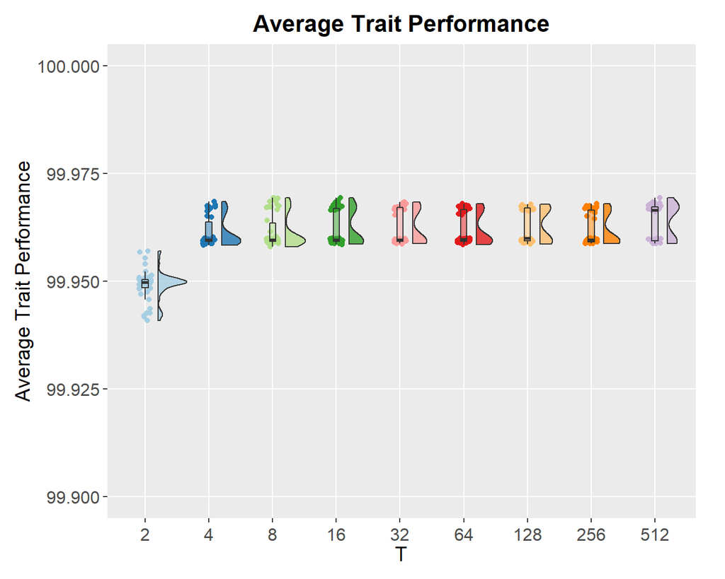

### 3.2.1 Stats Tests

The Kuskal-Wallis test finds evidence that groups do not come from the same distribution.

```r
kruskal.test(val ~ trt, data = df)
```

```
##
##  Kruskal-Wallis rank sum test
##
## data:  val by trt
## Kruskal-Wallis chi-squared = 139.99, df = 8, p-value < 2.2e-16
```

We see that there is no difference in performances found for sizes after 2, in terms of better performances found

```r
pairwise.wilcox.test(x = df$val, g = df$trt, p.adjust.method = "bonferroni", paired = FALSE, conf.int = TRUE, conf.level = .95, alternative = 't')
```

```
##
##  Pairwise comparisons using Wilcoxon rank sum test
##
## data:  df$val and df$trt
##
##     2       4    8    16   32   64   128  256
## 4   2.5e-16 -    -    -    -    -    -    -
## 8   2.5e-16 1.00 -    -    -    -    -    -
## 16  2.5e-16 1.00 1.00 -    -    -    -    -
## 32  2.5e-16 1.00 1.00 1.00 -    -    -    -
## 64  2.5e-16 1.00 1.00 1.00 1.00 -    -    -
## 128 2.5e-16 1.00 1.00 1.00 1.00 1.00 -    -
## 256 2.5e-16 1.00 1.00 1.00 1.00 1.00 1.00 -
## 512 2.5e-16 0.45 1.00 1.00 1.00 1.00 1.00 0.67
##
## P value adjustment method: bonferroni
```

# 4 Epsilon Lexicase Selection

Here we explore the impact of different epsilon values on the exploitation diagnostic.

## 4.1 Generation Solution Found Data

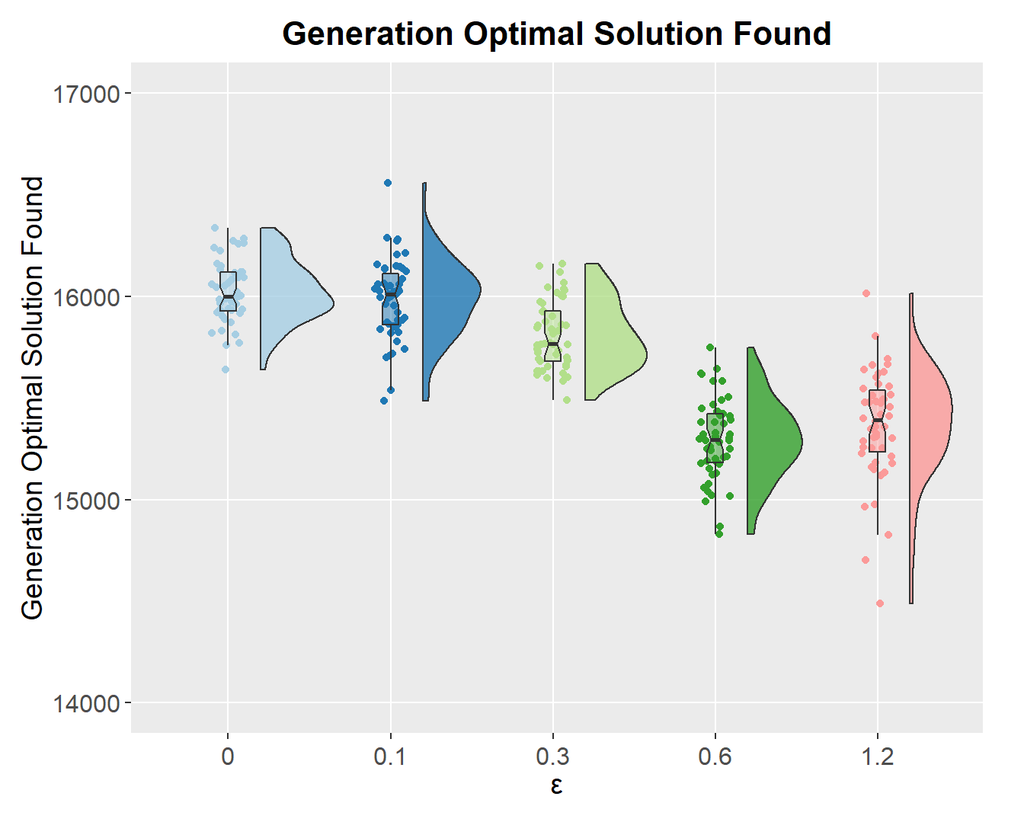

### 4.1.2 Summary Statistics

```r
do.call("rbind", tapply(df$Gen, df$e, summary))
```

```
##      Min.  1st Qu. Median     Mean  3rd Qu.  Max.
## 0   15638 15929.25  16000 16020.74 16117.50 16335
## 0.1 15485 15861.50  16009 15984.22 16112.25 16556
## 0.3 15490 15679.75  15765 15808.38 15926.25 16159
## 0.6 14828 15180.75  15294 15294.72 15421.00 15747
## 1.2 14487 15232.50  15392 15366.28 15537.25 16015
```

### 4.1.3 Stats Tests

The Kuskal-Wallis test finds evidence that groups do not come from the same distribution.

```r
kruskal.test(Gen ~ e, data = df)
```

```
##
##  Kruskal-Wallis rank sum test
##
## data:  Gen by e
## Kruskal-Wallis chi-squared = 179.81, df = 4, p-value < 2.2e-16
```

We find evidence of no difference between 0 & .1.

```r
pairwise.wilcox.test(x = df$Gen, g = df$e, p.adjust.method = "bonferroni", paired = FALSE, conf.int = TRUE, conf.level = .95, alternative = 'l')
```

```
##
##  Pairwise comparisons using Wilcoxon rank sum test
##
## data:  df$Gen and df$e
##
##     0       0.1     0.3     0.6
## 0.1 1       -       -       -
## 0.3 2.2e-07 3.8e-05 -       -
## 0.6 < 2e-16 < 2e-16 5.0e-16 -
## 1.2 2.8e-16 1.1e-15 1.6e-13 1
##
## P value adjustment method: bonferroni
```

## 4.2 Best Performance Found

We look at the best performances found throughout an evolutionary run to see if there is any differences in performances found.

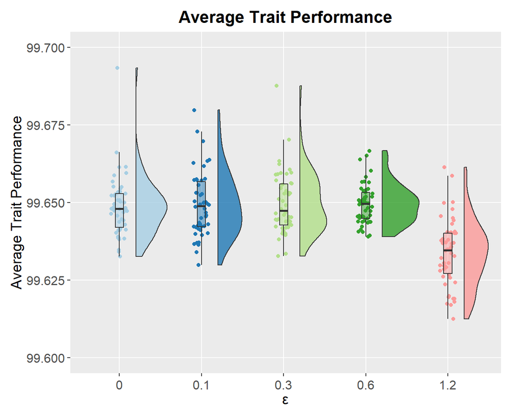

### 4.2.1 Stats Tests

The Kuskal-Wallis test finds evidence that groups do not come from the same distribution.

```r
kruskal.test(val ~ trt, data = df)
```

```
##
##  Kruskal-Wallis rank sum test
##
## data:  val by trt
## Kruskal-Wallis chi-squared = 70.402, df = 4, p-value = 1.867e-14
```

We see that there is no difference in performances for epsilon less than 1.2, in terms of better performances found.

```r
pairwise.wilcox.test(x = df$val, g = df$trt, p.adjust.method = "bonferroni", paired = FALSE, conf.int = TRUE, conf.level = .95, alternative = 't')
```

```
##
##  Pairwise comparisons using Wilcoxon rank sum test
##
## data:  df$val and df$trt
##
##     0       0.1     0.3     0.6
## 0.1 1       -       -       -
## 0.3 1       1       -       -
## 0.6 1       1       1       -
## 1.2 1.5e-09 4.2e-09 4.8e-10 1.8e-11
##
## P value adjustment method: bonferroni
```

# 5 Novelty Aggregate

Here we explore the impact of different nearest neighbor values on the exploitation diagnostic.

## 5.1 Best Performance Found

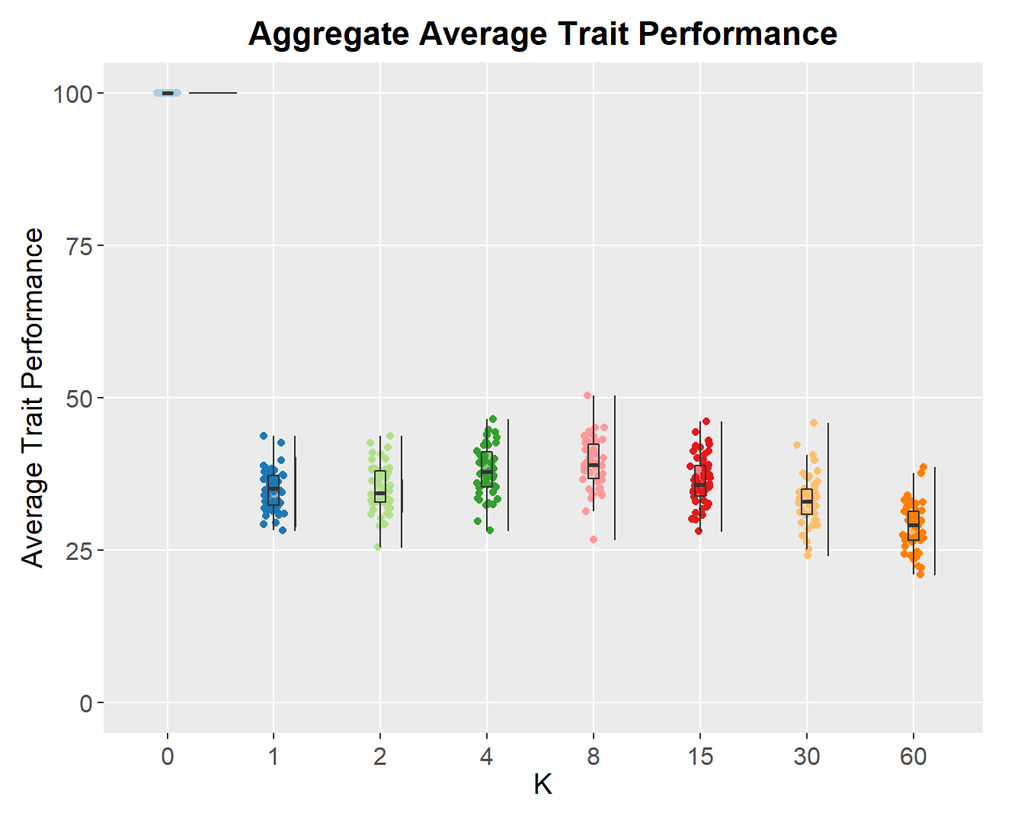

### 5.1.1 Summary Statistics

```r
do.call("rbind", tapply(df$val, df$trt, summary))
```

```
##       Min.  1st Qu.   Median     Mean  3rd Qu.    Max.
## 0  99.9587 99.95930 99.95970 99.96225 99.96715 99.9690
## 1  28.2452 32.45110 35.16650 35.01154 37.23745 43.7163
## 2  25.5287 32.88560 34.37160 35.09209 38.00825 43.7189
## 4  28.3099 35.43197 37.89030 38.03577 41.10055 46.4664
## 8  26.7461 36.74023 39.04635 39.18217 42.35743 50.3689
## 15 28.1580 33.88808 35.78005 36.38277 38.94123 46.1117
## 30 24.1921 30.86108 32.96385 33.17620 35.04098 45.8484
## 60 21.0534 26.61052 29.09355 28.88972 31.44040 38.6910
```

### 5.1.2 Stats Tests

The Kuskal-Wallis test finds evidence that groups do not come from the same distribution.

```r
df = filter(df, trt != 0)
kruskal.test(val ~ trt, data = df)
```

```
##
##  Kruskal-Wallis rank sum test
##
## data:  val by trt
## Kruskal-Wallis chi-squared = 135.37, df = 6, p-value < 2.2e-16
```

We find evidence that 4 & 8 perform statistically better, in terms of better performances found

```r
pairwise.wilcox.test(x = df$val, g = df$trt, p.adjust.method = "bonferroni", paired = FALSE, conf.int = TRUE, conf.level = .95, alternative = 'g')
```

```
##
##  Pairwise comparisons using Wilcoxon rank sum test
##
## data:  df$val and df$trt
##
##    1       2       4      8      15     30
## 2  1.0000  -       -      -      -      -
## 4  0.0029  0.0056  -      -      -      -
## 8  1.9e-06 1.1e-05 1.0000 -      -      -
## 15 1.0000  1.0000  1.0000 1.0000 -      -
## 30 1.0000  1.0000  1.0000 1.0000 1.0000 -
## 60 1.0000  1.0000  1.0000 1.0000 1.0000 1.0000
##
## P value adjustment method: bonferroni
```

```r
pairwise.wilcox.test(x = df$val, g = df$trt, p.adjust.method = "bonferroni", paired = FALSE, conf.int = TRUE, conf.level = .95, alternative = 'l')
```

```
##
##  Pairwise comparisons using Wilcoxon rank sum test
##
## data:  df$val and df$trt
##
##    1       2       4       8       15      30
## 2  1.0000  -       -       -       -       -
## 4  1.0000  1.0000  -       -       -       -
## 8  1.0000  1.0000  1.0000  -       -       -
## 15 1.0000  1.0000  0.4372  0.0065  -       -
## 30 0.1053  0.1809  1.7e-06 6.4e-09 0.0014  -
## 60 2.4e-10 3.6e-10 1.0e-13 1.0e-14 6.3e-12 9.1e-06
##
## P value adjustment method: bonferroni
```

# 6 Fitness Sharing

Here we explore the impact of different similarity thresholds on the exploitation diagnostic.

## 6.1 Generation Solution Found Data

As expected we see that fitness sharing slows down the rate at which optimal solutions are found, as there is pressure to diversify the population.

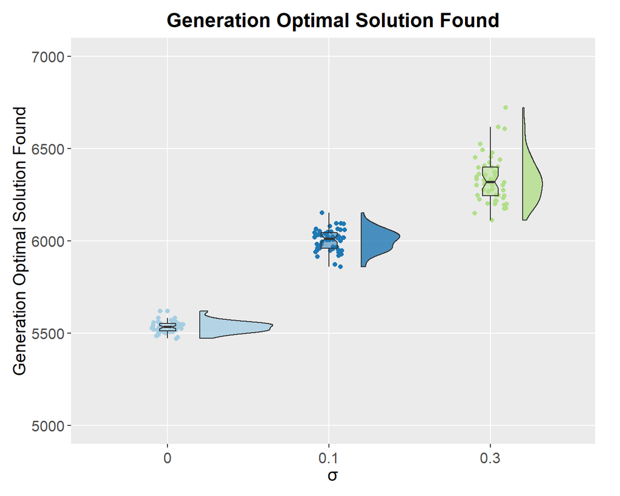

### 6.1.2 Summary Statistics

```r
do.call("rbind", tapply(df$Gen, df$s, summary))
```

```
##     Min. 1st Qu. Median    Mean 3rd Qu. Max.
## 0   5472 5512.00 5534.5 5534.26 5552.75 5621
## 0.1 5860 5960.25 6011.5 6003.72 6044.75 6152
## 0.3 6112 6244.75 6319.5 6331.00 6399.25 6722
```

### 6.1.3 Stats Tests

The Kuskal-Wallis test finds evidence that groups do not come from the same distribution.

```r
kruskal.test(Gen ~ s, data = df)
```

```
##
##  Kruskal-Wallis rank sum test
##
## data:  Gen by s
## Kruskal-Wallis chi-squared = 132.35, df = 2, p-value < 2.2e-16
```

The pairwaise Wilcoxon rank sum tests show evidence that 0 < .1 < .3.

```r
pairwise.wilcox.test(x = df$Gen, g = df$s, p.adjust.method = "bonferroni", paired = FALSE, conf.int = TRUE, conf.level = .95, alternative = 'g')
```

```
##
##  Pairwise comparisons using Wilcoxon rank sum test
##
## data:  df$Gen and df$s
##
##     0      0.1
## 0.1 <2e-16 -
## 0.3 <2e-16 <2e-16
##
## P value adjustment method: bonferroni
```

## 6.2 Best Performance Found

We look at the best performances found throughout an evolutionary run to see if there is any differences in performances found.

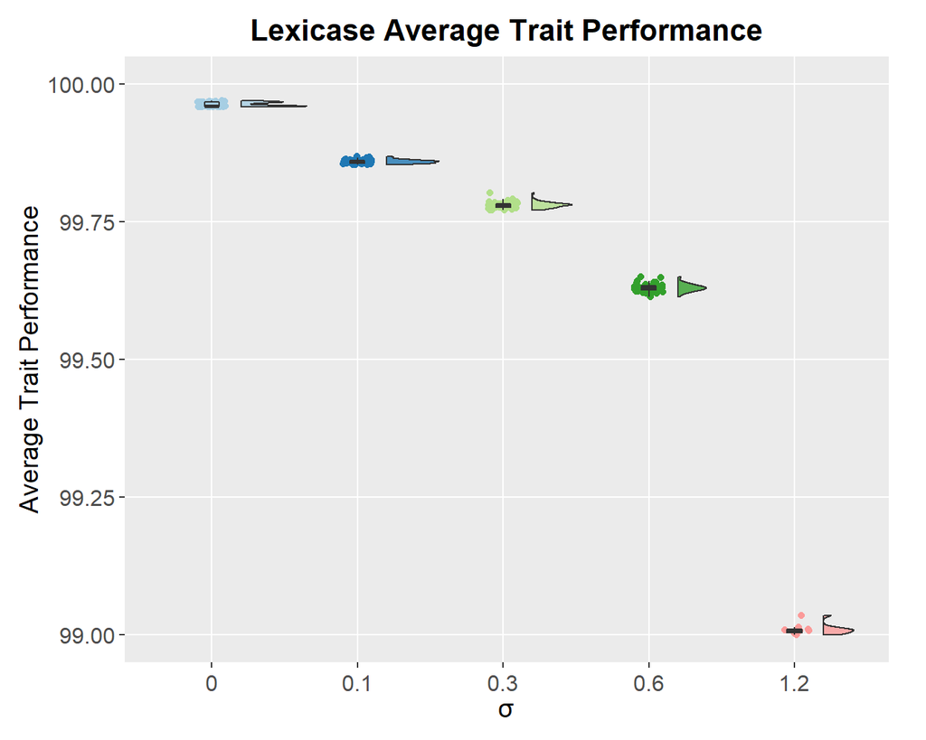

### 6.2.1 Stats Tests

The Kuskal-Wallis test finds evidence that groups do not come from the same distribution.

```r
kruskal.test(val ~ trt, data = df)
```

```
##
##  Kruskal-Wallis rank sum test
##
## data:  val by trt
## Kruskal-Wallis chi-squared = 239.05, df = 4, p-value < 2.2e-16
```

We find significant decreases in performance as the similarity threshold increases.

```r
pairwise.wilcox.test(x = df$val, g = df$trt, p.adjust.method = "bonferroni", paired = FALSE, conf.int = TRUE, conf.level = .95, alternative = 'l')
```

```
##
##  Pairwise comparisons using Wilcoxon rank sum test
##
## data:  df$val and df$trt
##
##     0      0.1    0.3    0.6
## 0.1 <2e-16 -      -      -
## 0.3 <2e-16 <2e-16 -      -
## 0.6 <2e-16 <2e-16 <2e-16 -
## 1.2 <2e-16 <2e-16 <2e-16 <2e-16
##
## P value adjustment method: bonferroni
```

# 7 Novelty Euclidean

## 7.1 Best Performance Found

As expected, novelty does not do well at this diagnostic.

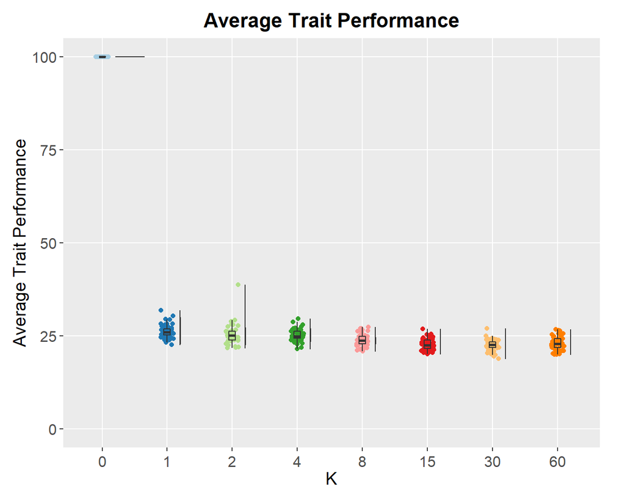

### 7.1.1 Summary Statistics

```r
do.call("rbind", tapply(df$val, df$trt, summary))
```

```
##       Min.  1st Qu.   Median     Mean  3rd Qu.    Max.
## 0  99.9582 99.95930 99.95960 99.96158 99.96593 99.9690
## 1  22.5991 25.26337 26.05235 26.31117 26.93593 31.8725
## 2  21.7916 23.96290 25.19330 25.38455 26.25445 38.7393
## 4  21.5649 24.38002 24.96190 25.23364 26.33665 29.6006
## 8  20.9453 22.88403 23.82190 23.88171 24.91880 27.4482
## 15 20.2096 21.62645 22.48185 22.75348 23.93885 26.8843
## 30 18.8870 21.87360 22.68645 22.55556 23.34842 26.9868
## 60 20.0503 21.96837 22.86420 22.98055 24.22515 26.8005
```

### 7.1.2 Stats Tests

The Kuskal-Wallis test finds evidence that groups do not come from the same distribution.

```r
df = filter(df, trt != 0)
kruskal.test(val ~ trt, data = df)
```

```
##
##  Kruskal-Wallis rank sum test
##
## data:  val by trt
## Kruskal-Wallis chi-squared = 146.59, df = 6, p-value < 2.2e-16
```

We find evidence that all parameters are statictically lower than 1, in terms of better performances found.

```r
pairwise.wilcox.test(x = df$val, g = df$trt, p.adjust.method = "bonferroni", paired = FALSE, conf.int = TRUE, conf.level = .95, alternative = 'l')
```

```
##
##  Pairwise comparisons using Wilcoxon rank sum test
##
## data:  df$val and df$trt
##
##    1       2       4       8      15     30
## 2  0.0204  -       -       -      -      -
## 4  0.0177  1.0000  -       -      -      -
## 8  7.5e-08 0.0048  0.0011  -      -      -
## 15 2.5e-13 2.1e-08 9.8e-10 0.0102 -      -
## 30 4.9e-14 1.6e-09 3.8e-11 0.0017 1.0000 -
## 60 6.6e-12 1.4e-06 8.1e-08 0.1258 1.0000 1.0000
##
## P value adjustment method: bonferroni
```